# Using the Wishart

Our model is that the *expected* covariance has a certain parametric form, which is a function of distance, and the *observed* covariance matrix has a Wishart distribution with mean equal to a certain $\Omega$ (times the number of loci), and that the observed covariance matrix, $\Sigma$, has
$$L \Sigma \sim \text{Wishart}(L,\Omega),$$
where $L$ is the number of loci.

## The Wishart

Recall that the Wishart is the distribution of $L \Sigma = X^T X$, where $X$ is a $L \times n$ matrix of Gaussians, whose rows are independent $N(0,\Omega)$.

- The mean of the Wishart is $L \Omega$,
- **the mode is $(L-n-1)\Omega$,**
- and the variance of $\Sigma_{ij}$ is $(\Omega_{ij}^2 + \Omega_{ii}\Omega_{jj})/L$.

### The mean

The assumption that rows are independent is not required to have $\E[ X^T X ] = L \Omega$, only that $\E[X_{i\ell}X_{j\ell}]=\Omega_{ij}$:
$$\begin{aligned}
\E[ (X^T X)_{ij} ]
&=
\EE{ \sum_{\ell=1}^L X_{i\ell} X_{j\ell} } \\
&=
\sum_{\ell=1}^L \E[ X_{i\ell} X_{j\ell} ] \\
&=
L \Omega_{ij} .
\end{aligned}$$

### The variance

Nonindependence, however, affects the variance:
$$\begin{aligned}
\var[ (X^T X)_{ij} ]
&=
\E\left[ \left( \sum_{\ell=1}^L X_{i\ell} X_{j\ell} \right)^2 \right] - L ^2 \Omega_{ij}^2 \\
&=
\E\left[ \sum_{k,\ell=1}^L X_{ik} X_{jk} X_{i\ell} X_{j\ell} \right]- L^2 \Omega_{ij}^2 \\
\end{aligned}$$
If the $X$s are Gaussian, then since for Gaussian $A$, $B$, $C$, $D$, $\E[ABCD]=\E[AB]\E[CD]+\E[AC][\E[BD]+\E[AD]\E[BC]$, this is equal to
$$\begin{aligned}
&=
\sum_{k,\ell=1}^L
% \E[ X_{ik} X_{jk} ] \E[ X_{i\ell} X_{j\ell} ] + % cancels with \Omega_{ij}^2
\E[ X_{ik} X_{j\ell} ] \E[ X_{i\ell} X_{jk} ]
+ \E[ X_{ik} X_{i\ell} ] \E[ X_{j\ell} X_{jk} ] \\
&= L ( \Omega_{ij}^2 + \Omega_{ii}\Omega_{jj} )
+ \sum_{k \neq \ell}
\E[ X_{ik} X_{j\ell} ] \E[ X_{i\ell} X_{jk} ]
+ \E[ X_{ik} X_{i\ell} ] \E[ X_{j\ell} X_{jk} ] .
\end{aligned}$$
This will in general increase the variance.

Suppose that it was true that the variance was inflated by a constant amount:
$$\var[ (X^T X)_{ij} ] = (L+C) ( \Omega_{ij}^2 + \Omega_{ii}\Omega_{jj} )$$
To approximate this by a Wishart($M$,$V$), we want $MV=L\Sigma$ and $MV^2=(L+C)\Sigma^2$, which is solved by $V=\Sigma L/M$ and $L^2/M=(L+C)$, i.e.
$$L \Sigma \sim \text{Wishart}\left( \frac{L^2}{L+C}, \frac{L+C}{L} \Sigma \right) .$$

## Allele frequencies

The distribution we're actually modeling is: pick "ancestral" allele frequencies $\mu$; pick allele frequencies $F=\mu+X$ by truncating a sample from $N(\mu,\mu(1-\mu)V)$, doing independent Binomial sampling $B$ from these with sample sizes $n$, and letting $\Sigma$ be the covariance matrix of the sample allele frequencies $P$.

What is the expected covariance matrix for this sampling scheme? We at least know that
$$\begin{aligned}
\cov[P_i,P_j]
&=
\E[ \cov[P_i,P_j|F] ] + \cov[ \E[P_i|F], \E[P_j|F] ] \\
&=
\delta_{ij} \frac{1}{n_i} \E[F_i (1-F_i)] + \cov[F_i,F_j] .
\end{aligned}$$
If $\E[F_i|\mu] = \mu$ and $\cov[F_i,F_j|\mu] = \mu(1-\mu)V_{ij}$, as would be the case if we ignored truncation, then
$$\begin{aligned}
\cov[F_i,F_j]
&=
\E[\cov[F_i,F_j|\mu]] + \cov[ \E[F_i|\mu], \E[F_j|\mu] ] \\
&=
\E[\mu(1-\mu)] V_{ij} + \var[\mu] \\
% &=
% \E[\mu](1-\E[\mu]) V_{ij} + (1-V_{ij})\var[\mu] ,
\end{aligned}$$
and also
$$\begin{aligned}
\E[ F_i (1-F_i) ]
&=
\E[ F_i ] - \E[ F_i ]^2 - \var[ F_i ] \\
&=
\E[ \mu ] ( 1- \E[\mu] ) - ( \E[\mu(1-\mu)] V_{ii} + \var[\mu] ) \\
&=
\E[ \mu (1-\mu) ] (1-V_{ii})
\end{aligned}$$
and so finally
$$\begin{aligned}
\cov[P_i,P_j]
&=
\delta_{ij} \frac{1}{n_i} \E[ \mu (1-\mu) ] (1-V_{ii})
+ \var[\mu] + \E[\mu(1-\mu)] V_{ij}
\end{aligned}$$
This suggests the parametric form
$$\Omega_{ij} = \zeta \left( \delta_{ij} \eta_i + V_{ij} \right) + \gamma .$$
Note that $\zeta$ is confounded with $\eta$ and $V$, so it should probably be left out.

# Simulation

## Pure Wishart

Let's take
$$\Omega_{ij} = \alpha_0 \exp\left( - \alpha_D d_{ij} \right).$$
We'll fix the sample locations, and hence $d$, as well as $\alpha_0$ and $\alpha_D$, once and for all.

```r
set.seed(42)
ninds <- 100
xy <- cbind(x=runif(ninds), y=runif(ninds))
dmat <- as.matrix( dist(xy) )
a0 <- 0.5
aD <- 1
Omega <- a0 * exp( - aD * dmat )
```

First, let's see what a few individual Wishart samples look like. Note the global correlation: the entire cloud of samples tends to be above or below the mean at the same time.

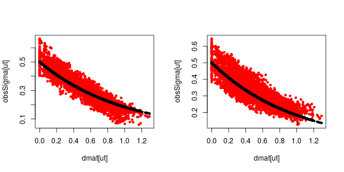

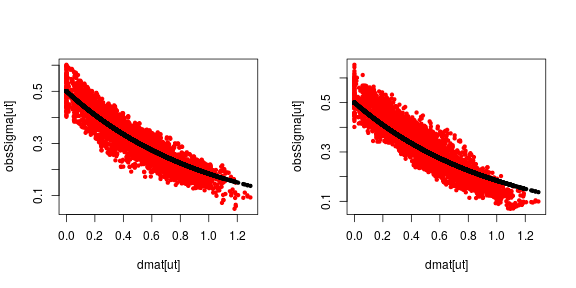

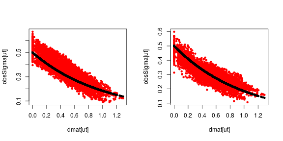

```r
ut <- upper.tri(dmat,diag=TRUE)
L <- 1e2
layout(t(1:2))
for (k in 1:6) {
    obsSigma <- rWishart( n=1, df=L, Sigma=Omega )[,,] / L
    plot( dmat[ut], obsSigma[ut], pch=20, col='red' )
    points( dmat[ut], Omega[ut], pch=20 )
}
```

Here's distributions of many Wisharts:

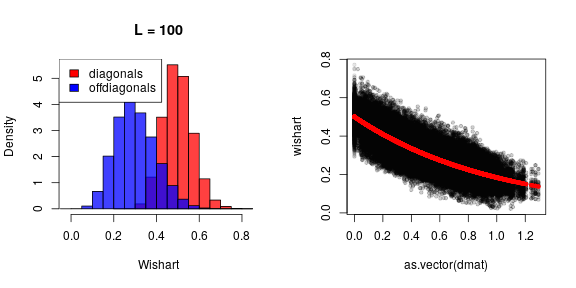

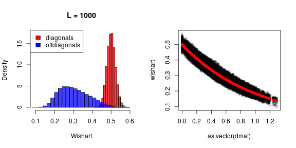

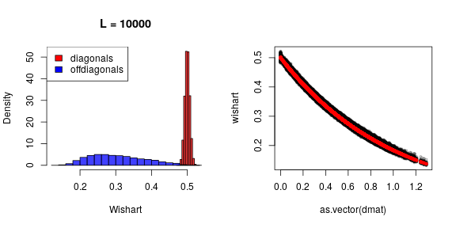

```r
dummy.mat <- matrix(0,nrow=ninds,ncol=ninds)
diag.inds <- which( row(dummy.mat)==col(dummy.mat) )
utri <- which( upper.tri(dummy.mat, diag=FALSE) )
for (L in c(1e2, 1e3, 1e4)) {
    wishart.samples <- rWishart( n=1000, df=L, Sigma=Omega ) / L
    dim(wishart.samples) <- c( ninds^2, 1000 )
    layout(t(1:2))
    hist( wishart.samples[diag.inds,], col=adjustcolor("red",0.75), xlim=range(wishart.samples), freq=FALSE, xlab='Wishart', main=sprintf("L = %d", L) )
        hist( wishart.samples[utri,], col=adjustcolor("blue",0.75), add=TRUE, freq=FALSE )
        legend("topleft",fill=c("red","blue"),legend=c("diagonals","offdiagonals"))
    matplot( as.vector(dmat), wishart.samples[,1:20], pch=20, col=adjustcolor("black",0.1), ylab='wishart' )
    points( as.vector(dmat), as.vector(Omega), col='red', pch=20 )
}
```

Plots of individual matrix elements don't show anything significantly different.

### Stan

Let's see what the posterior distribution looks like in this simple case.

```r
wishart.stan <- "
data {
    int<lower=2> N;             // number of samples
    int<lower=N+1> L;           // number of loci
    matrix[N,N] obsSigma;       // observed covar
    matrix[N,N]  geoDist;       // matrix of pairwise geographic distance
}
parameters {
    real<lower=0> alpha0;               // sill of the parametric covariance in cluster k
    real<lower=0> alphaD;               // effect of geographic distance in the parametric covariance in cluster k
}
transformed parameters {
    matrix[N,N] Sigma;      // this specifies the parametric, admixed covariance matrix
    for (i in 1:N){
        for (j in i:N){
                Sigma[i, j] <- alpha0 * exp(-(alphaD * geoDist[i, j]) );
                Sigma[j, i] <- Sigma[i, j];
        }
    }
}
model {
    alpha0 ~ exponential(1);                                // prior on alpha0
    alphaD ~ exponential(1);                                // prior on alphaD
    (L*obsSigma) ~ wishart(L,Sigma);                        // likelihood function
}
"
set.seed(23)
L <- 1e3
obsSigma <- rWishart( n=1, df=L, Sigma=Omega )[,,] / L
data.block <- list( "N" = ninds,
                    "L" = L,
                    "obsSigma" = obsSigma,
                    "geoDist" = dmat )
n.iter <- 1e4
fit <- stan( model_code = wishart.stan, data = data.block, iter=n.iter, chains = 1, thin=n.iter/500)
```

[output not shown]

[output not shown]

[output not shown]

[output not shown]

[output not shown]

[output not shown]

In the result, $\alpha_0$ and $\alpha_D$ are strongly negatively correlated:

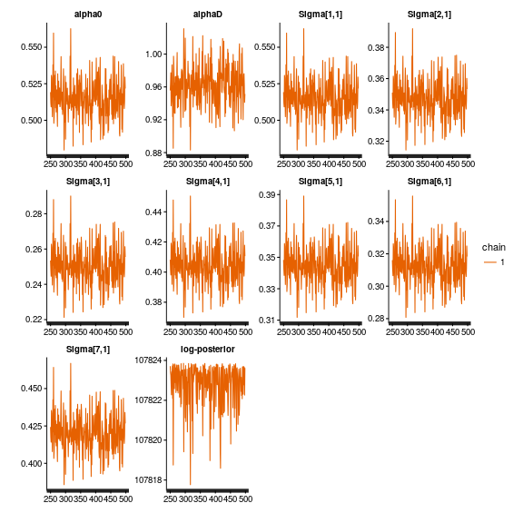

```r
traceplot( fit, pars=c(names(fit)[1:9],"lp__") )
```

[output not shown]

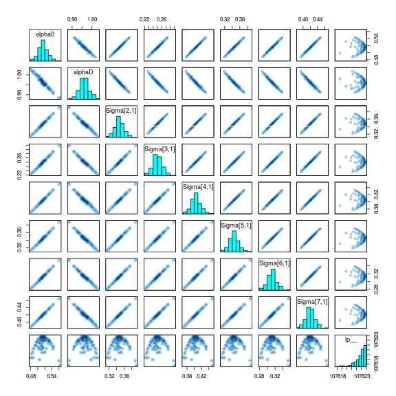

```r
pairs( fit, pars=c(names(fit)[1:9],"lp__") )
```

Let's compare the posterior samples to the expected value and the sample we fed in. First, here's the posterior mean Sigma, the transform of the posterior mean $\alpha_0$ and $\alpha_D$, the "true" value, and the "observed" $\Sigma$; shown first in absolute scale, then as difference to $\Omega$.

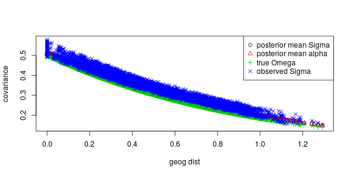

```r
ut <- upper.tri(dmat,diag=TRUE)
alpha.pm <- get_posterior_mean( fit, pars=c("alpha0","alphaD") )
post.Sigma <- matrix( get_posterior_mean( fit, pars=grep("Sigma",names(fit), value=TRUE) ), nrow=ninds )
post.Omega <- alpha.pm["alpha0",1] * exp( - alpha.pm["alphaD",1] * dmat )
matplot( dmat[ut], cbind( post.Sigma[ut], post.Omega[ut], Omega[ut], obsSigma[ut] ), pch=1:4, ylab="covariance", xlab='geog dist' )
legend("topright", pch=1:4, col=1:5, legend=c("posterior mean Sigma", "posterior mean alpha", "true Omega", "observed Sigma"))
```

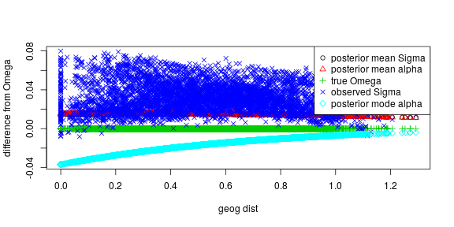

```r
matplot( dmat[ut], cbind( post.Sigma[ut]-Omega[ut], post.Omega[ut]-Omega[ut], 0, obsSigma[ut]-Omega[ut], (1-(ninds+1)/L)*post.Omega[ut]-Omega[ut] ), pch=1:5, ylab="difference from Omega", xlab='geog dist' )
legend("topright", pch=1:5, col=1:5, legend=c("posterior mean Sigma", "posterior mean alpha", "true Omega", "observed Sigma", "posterior mode alpha"))
```

Now, here's the posterior distribution of Wishart samples (in grey), along with the "observed" sigma (red) and the "true" mean (black):

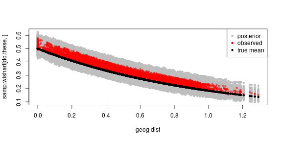

```r
samp.wishart <- (1/L) * apply( as.matrix(fit)[,3:(ninds^2+2)], 1, function (O) { rWishart(1, df=data.block$L, Sigma=matrix(O,nrow=ninds)) } )
col.inds <- do.call(rbind,strsplit(gsub("[][]","",gsub("Sigma","",names(fit)[3:(ninds^2+2)])),","))
do.these <- which( col.inds[,1] <= col.inds[,2] )
matplot( dmat[col.inds[do.these,]], samp.wishart[do.these,], pch=20, col='grey', xlab='geog dist' )
points( dmat[ut], obsSigma[ut], pch=20, col=adjustcolor('red',0.5) )
points( dmat[ut], Omega[ut], pch=20 )
legend("topright",pch=20,col=c('grey','red','black'),legend=c("posterior","observed","true mean"))
```